# Risk Factor Analysis

## Outcome Variable

**Outcome Variable:** sstunted

## Predictor Variables

**Intervention Variable:** tr

**Adjustment Set:**

unadjusted

## Stratifying Variables

The analysis was stratified on these variable(s):

- agecat
- studyid
- country
- intXnchldlt5

## Data Summary

| agecat | studyid | country | intXnchldlt5 | sstunted | n_cell | n |
| --- | --- | --- | --- | --- | --- | --- |
| Birth | kiGH5241-JiVitA-3 | BANGLADESH | 1_Birth | 0 | 21292 | 24208 |
| Birth | kiGH5241-JiVitA-3 | BANGLADESH | 1_Birth | 1 | 2916 | 24208 |
| Birth | kiGH5241-JiVitA-3 | BANGLADESH | 2+_Birth | 0 | 850 | 934 |
| Birth | kiGH5241-JiVitA-3 | BANGLADESH | 2+_Birth | 1 | 84 | 934 |
| 6 months | iLiNS_DYADM_LNS | MALAWI | 1_6 months | 0 | 41 | 42 |
| 6 months | iLiNS_DYADM_LNS | MALAWI | 1_6 months | 1 | 1 | 42 |
| 6 months | iLiNS_DYADM_LNS | MALAWI | 2+_6 months | 0 | 33 | 33 |
| 6 months | iLiNS_DYADM_LNS | MALAWI | 2+_6 months | 1 | 0 | 33 |
| 6 months | ki1000107-Serrinha-VitA | BRAZIL | 1_6 months | 0 | 15 | 16 |
| 6 months | ki1000107-Serrinha-VitA | BRAZIL | 1_6 months | 1 | 1 | 16 |
| 6 months | ki1000107-Serrinha-VitA | BRAZIL | 2+_6 months | 0 | 6 | 6 |
| 6 months | ki1000107-Serrinha-VitA | BRAZIL | 2+_6 months | 1 | 0 | 6 |
| 6 months | ki1017093b-PROVIDE | BANGLADESH | 1_6 months | 0 | 29 | 29 |
| 6 months | ki1017093b-PROVIDE | BANGLADESH | 1_6 months | 1 | 0 | 29 |
| 6 months | ki1066203-TanzaniaChild2 | TANZANIA, UNITED REPUBLIC OF | 1_6 months | 0 | 1161 | 1173 |
| 6 months | ki1066203-TanzaniaChild2 | TANZANIA, UNITED REPUBLIC OF | 1_6 months | 1 | 12 | 1173 |
| 6 months | ki1066203-TanzaniaChild2 | TANZANIA, UNITED REPUBLIC OF | 2+_6 months | 0 | 52 | 53 |
| 6 months | ki1066203-TanzaniaChild2 | TANZANIA, UNITED REPUBLIC OF | 2+_6 months | 1 | 1 | 53 |
| 6 months | ki1148112-iLiNS-DOSE | MALAWI | 1_6 months | 0 | 785 | 845 |
| 6 months | ki1148112-iLiNS-DOSE | MALAWI | 1_6 months | 1 | 60 | 845 |
| 6 months | ki1148112-iLiNS-DOSE | MALAWI | 2+_6 months | 0 | 132 | 150 |
| 6 months | ki1148112-iLiNS-DOSE | MALAWI | 2+_6 months | 1 | 18 | 150 |
| 6 months | ki1148112-iLiNS-DYAD-M | MALAWI | 1_6 months | 0 | 58 | 60 |
| 6 months | ki1148112-iLiNS-DYAD-M | MALAWI | 1_6 months | 1 | 2 | 60 |
| 6 months | ki1148112-iLiNS-DYAD-M | MALAWI | 2+_6 months | 0 | 43 | 43 |
| 6 months | ki1148112-iLiNS-DYAD-M | MALAWI | 2+_6 months | 1 | 0 | 43 |
| 6 months | ki1148112-LCNI-5 | MALAWI | 1_6 months | 0 | 362 | 390 |
| 6 months | ki1148112-LCNI-5 | MALAWI | 1_6 months | 1 | 28 | 390 |
| 6 months | ki1148112-LCNI-5 | MALAWI | 2+_6 months | 0 | 58 | 63 |
| 6 months | ki1148112-LCNI-5 | MALAWI | 2+_6 months | 1 | 5 | 63 |
| 6 months | kiGH5241-JiVitA-3 | BANGLADESH | 1_6 months | 0 | 20252 | 21667 |
| 6 months | kiGH5241-JiVitA-3 | BANGLADESH | 1_6 months | 1 | 1415 | 21667 |
| 6 months | kiGH5241-JiVitA-3 | BANGLADESH | 2+_6 months | 0 | 677 | 719 |
| 6 months | kiGH5241-JiVitA-3 | BANGLADESH | 2+_6 months | 1 | 42 | 719 |
| 24 months | iLiNS_DYADM_LNS | MALAWI | 2+_24 months | 0 | 1 | 2 |
| 24 months | iLiNS_DYADM_LNS | MALAWI | 2+_24 months | 1 | 1 | 2 |
| 24 months | ki1000107-Serrinha-VitA | BRAZIL | 1_24 months | 0 | 45 | 50 |
| 24 months | ki1000107-Serrinha-VitA | BRAZIL | 1_24 months | 1 | 5 | 50 |
| 24 months | ki1000107-Serrinha-VitA | BRAZIL | 2+_24 months | 0 | 19 | 29 |
| 24 months | ki1000107-Serrinha-VitA | BRAZIL | 2+_24 months | 1 | 10 | 29 |
| 24 months | ki1017093b-PROVIDE | BANGLADESH | 1_24 months | 0 | 1 | 1 |
| 24 months | ki1017093b-PROVIDE | BANGLADESH | 1_24 months | 1 | 0 | 1 |
| 24 months | ki1066203-TanzaniaChild2 | TANZANIA, UNITED REPUBLIC OF | 1_24 months | 0 | 3 | 4 |
| 24 months | ki1066203-TanzaniaChild2 | TANZANIA, UNITED REPUBLIC OF | 1_24 months | 1 | 1 | 4 |
| 24 months | ki1148112-iLiNS-DOSE | MALAWI | 1_24 months | 0 | 284 | 347 |
| 24 months | ki1148112-iLiNS-DOSE | MALAWI | 1_24 months | 1 | 63 | 347 |
| 24 months | ki1148112-iLiNS-DOSE | MALAWI | 2+_24 months | 0 | 37 | 59 |
| 24 months | ki1148112-iLiNS-DOSE | MALAWI | 2+_24 months | 1 | 22 | 59 |
| 24 months | ki1148112-iLiNS-DYAD-M | MALAWI | 2+_24 months | 0 | 1 | 2 |
| 24 months | ki1148112-iLiNS-DYAD-M | MALAWI | 2+_24 months | 1 | 1 | 2 |
| 24 months | ki1148112-LCNI-5 | MALAWI | 1_24 months | 0 | 166 | 181 |
| 24 months | ki1148112-LCNI-5 | MALAWI | 1_24 months | 1 | 15 | 181 |
| 24 months | ki1148112-LCNI-5 | MALAWI | 2+_24 months | 0 | 26 | 26 |
| 24 months | ki1148112-LCNI-5 | MALAWI | 2+_24 months | 1 | 0 | 26 |
| 24 months | kiGH5241-JiVitA-3 | BANGLADESH | 1_24 months | 0 | 90 | 121 |
| 24 months | kiGH5241-JiVitA-3 | BANGLADESH | 1_24 months | 1 | 31 | 121 |
| 24 months | kiGH5241-JiVitA-3 | BANGLADESH | 2+_24 months | 0 | 3 | 5 |
| 24 months | kiGH5241-JiVitA-3 | BANGLADESH | 2+_24 months | 1 | 2 | 5 |

The following strata were considered:

- agecat: 24 months, studyid: iLiNS_DYADM_LNS, country: MALAWI, intXnchldlt5: 2+_24 months
- agecat: 24 months, studyid: ki1000107-Serrinha-VitA, country: BRAZIL, intXnchldlt5: 1_24 months
- agecat: 24 months, studyid: ki1000107-Serrinha-VitA, country: BRAZIL, intXnchldlt5: 2+_24 months
- agecat: 24 months, studyid: ki1017093b-PROVIDE, country: BANGLADESH, intXnchldlt5: 1_24 months
- agecat: 24 months, studyid: ki1066203-TanzaniaChild2, country: TANZANIA, UNITED REPUBLIC OF, intXnchldlt5: 1_24 months
- agecat: 24 months, studyid: ki1148112-iLiNS-DOSE, country: MALAWI, intXnchldlt5: 1_24 months
- agecat: 24 months, studyid: ki1148112-iLiNS-DOSE, country: MALAWI, intXnchldlt5: 2+_24 months
- agecat: 24 months, studyid: ki1148112-iLiNS-DYAD-M, country: MALAWI, intXnchldlt5: 2+_24 months
- agecat: 24 months, studyid: ki1148112-LCNI-5, country: MALAWI, intXnchldlt5: 1_24 months
- agecat: 24 months, studyid: ki1148112-LCNI-5, country: MALAWI, intXnchldlt5: 2+_24 months
- agecat: 24 months, studyid: kiGH5241-JiVitA-3, country: BANGLADESH, intXnchldlt5: 1_24 months
- agecat: 24 months, studyid: kiGH5241-JiVitA-3, country: BANGLADESH, intXnchldlt5: 2+_24 months
- agecat: 6 months, studyid: iLiNS_DYADM_LNS, country: MALAWI, intXnchldlt5: 1_6 months
- agecat: 6 months, studyid: iLiNS_DYADM_LNS, country: MALAWI, intXnchldlt5: 2+_6 months
- agecat: 6 months, studyid: ki1000107-Serrinha-VitA, country: BRAZIL, intXnchldlt5: 1_6 months
- agecat: 6 months, studyid: ki1000107-Serrinha-VitA, country: BRAZIL, intXnchldlt5: 2+_6 months
- agecat: 6 months, studyid: ki1017093b-PROVIDE, country: BANGLADESH, intXnchldlt5: 1_6 months
- agecat: 6 months, studyid: ki1066203-TanzaniaChild2, country: TANZANIA, UNITED REPUBLIC OF, intXnchldlt5: 1_6 months
- agecat: 6 months, studyid: ki1066203-TanzaniaChild2, country: TANZANIA, UNITED REPUBLIC OF, intXnchldlt5: 2+_6 months
- agecat: 6 months, studyid: ki1148112-iLiNS-DOSE, country: MALAWI, intXnchldlt5: 1_6 months
- agecat: 6 months, studyid: ki1148112-iLiNS-DOSE, country: MALAWI, intXnchldlt5: 2+_6 months
- agecat: 6 months, studyid: ki1148112-iLiNS-DYAD-M, country: MALAWI, intXnchldlt5: 1_6 months
- agecat: 6 months, studyid: ki1148112-iLiNS-DYAD-M, country: MALAWI, intXnchldlt5: 2+_6 months
- agecat: 6 months, studyid: ki1148112-LCNI-5, country: MALAWI, intXnchldlt5: 1_6 months
- agecat: 6 months, studyid: ki1148112-LCNI-5, country: MALAWI, intXnchldlt5: 2+_6 months
- agecat: 6 months, studyid: kiGH5241-JiVitA-3, country: BANGLADESH, intXnchldlt5: 1_6 months
- agecat: 6 months, studyid: kiGH5241-JiVitA-3, country: BANGLADESH, intXnchldlt5: 2+_6 months
- agecat: Birth, studyid: kiGH5241-JiVitA-3, country: BANGLADESH, intXnchldlt5: 1_Birth
- agecat: Birth, studyid: kiGH5241-JiVitA-3, country: BANGLADESH, intXnchldlt5: 2+_Birth

### Dropped Strata

Some strata were dropped due to rare outcomes:

- agecat: 6 months, studyid: iLiNS_DYADM_LNS, country: MALAWI, intXnchldlt5: 1_6 months
- agecat: 6 months, studyid: iLiNS_DYADM_LNS, country: MALAWI, intXnchldlt5: 2+_6 months
- agecat: 6 months, studyid: ki1000107-Serrinha-VitA, country: BRAZIL, intXnchldlt5: 1_6 months
- agecat: 6 months, studyid: ki1000107-Serrinha-VitA, country: BRAZIL, intXnchldlt5: 2+_6 months
- agecat: 6 months, studyid: ki1017093b-PROVIDE, country: BANGLADESH, intXnchldlt5: 1_6 months
- agecat: 6 months, studyid: ki1066203-TanzaniaChild2, country: TANZANIA, UNITED REPUBLIC OF, intXnchldlt5: 2+_6 months
- agecat: 6 months, studyid: ki1148112-iLiNS-DYAD-M, country: MALAWI, intXnchldlt5: 1_6 months
- agecat: 6 months, studyid: ki1148112-iLiNS-DYAD-M, country: MALAWI, intXnchldlt5: 2+_6 months
- agecat: 24 months, studyid: iLiNS_DYADM_LNS, country: MALAWI, intXnchldlt5: 2+_24 months
- agecat: 24 months, studyid: ki1017093b-PROVIDE, country: BANGLADESH, intXnchldlt5: 1_24 months
- agecat: 24 months, studyid: ki1066203-TanzaniaChild2, country: TANZANIA, UNITED REPUBLIC OF, intXnchldlt5: 1_24 months
- agecat: 24 months, studyid: ki1148112-iLiNS-DYAD-M, country: MALAWI, intXnchldlt5: 2+_24 months
- agecat: 24 months, studyid: ki1148112-LCNI-5, country: MALAWI, intXnchldlt5: 2+_24 months
- agecat: 24 months, studyid: kiGH5241-JiVitA-3, country: BANGLADESH, intXnchldlt5: 2+_24 months

## Methods Detail

We’re interested in the causal parameters $E[Y_a]$ for all values of $a \in \mathcal{A}$. These parameters represent the mean outcome if, possibly contrary to fact, we intervened to set all units to have $A=a$. Under the randomization and positivity assumptions, these are identified by the statistical parameters $\psi_a=E_W[E_{Y|A,W}(Y|A=a,W)]$. In addition, we’re interested in the mean of $Y$, $E[Y]$ under no intervention (the observed mean). We will estimate these parameters by using SuperLearner to fit the relevant likelihood factors – $E_{Y|A,W}(Y|A=a,W)$ and $p(A=a|W)$, and then updating our likelihood fit using a joint TMLE.

For unadjusted analyses ($W=\{\}$), initial likelihoods were estimated using Lrnr_glm to estimate the simple $E(Y|A)$ and Lrnr_mean to estimate $p(A)$. For adjusted analyses, a small library containing Lrnr_glmnet, Lrnr_xgboost, and Lrnr_mean was used.

Having estimated these parameters, we will then use the delta method to estimate relative risks and attributable risks relative to a prespecified baseline level of $A$.

# Results Detail

## Results Plots

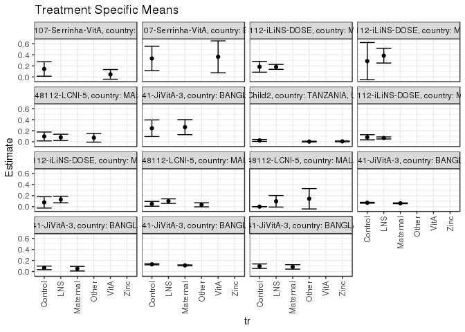

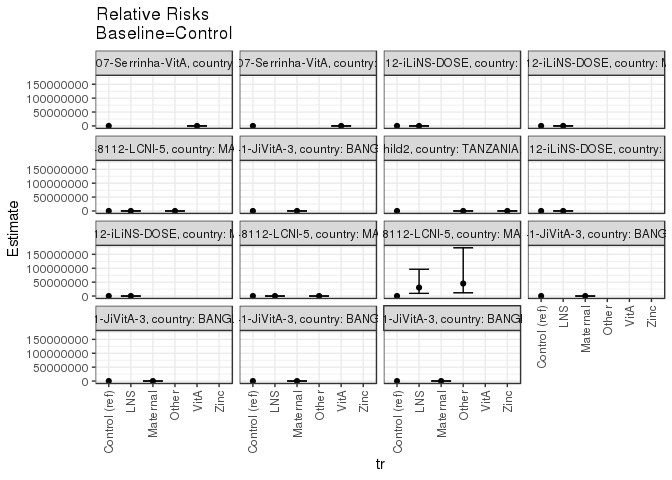

[figure not shown]

[figure not shown]

## Results Table

### Parameter: TSM

| agecat | studyid | country | intXnchldlt5 | intervention_level | baseline_level | estimate | ci_lower | ci_upper |
| --- | --- | --- | --- | --- | --- | --- | --- | --- |
| Birth | kiGH5241-JiVitA-3 | BANGLADESH | 1_Birth | Control | NA | 0.1304710 | 0.1211751 | 0.1397669 |
| Birth | kiGH5241-JiVitA-3 | BANGLADESH | 1_Birth | Maternal | NA | 0.1105824 | 0.1021352 | 0.1190297 |
| Birth | kiGH5241-JiVitA-3 | BANGLADESH | 2+_Birth | Control | NA | 0.0962343 | 0.0553435 | 0.1371251 |
| Birth | kiGH5241-JiVitA-3 | BANGLADESH | 2+_Birth | Maternal | NA | 0.0833333 | 0.0431163 | 0.1235503 |
| 6 months | ki1066203-TanzaniaChild2 | TANZANIA, UNITED REPUBLIC OF | 1_6 months | Control | NA | 0.0238095 | 0.0063753 | 0.0412437 |
| 6 months | ki1066203-TanzaniaChild2 | TANZANIA, UNITED REPUBLIC OF | 1_6 months | Other | NA | 0.0032680 | -0.0031294 | 0.0096653 |
| 6 months | ki1066203-TanzaniaChild2 | TANZANIA, UNITED REPUBLIC OF | 1_6 months | Zinc | NA | 0.0069808 | 0.0001608 | 0.0138009 |
| 6 months | ki1148112-iLiNS-DOSE | MALAWI | 1_6 months | Control | NA | 0.0814815 | 0.0353060 | 0.1276570 |
| 6 months | ki1148112-iLiNS-DOSE | MALAWI | 1_6 months | LNS | NA | 0.0690141 | 0.0503582 | 0.0876700 |
| 6 months | ki1148112-iLiNS-DOSE | MALAWI | 2+_6 months | Control | NA | 0.0769231 | -0.0258457 | 0.1796919 |
| 6 months | ki1148112-iLiNS-DOSE | MALAWI | 2+_6 months | LNS | NA | 0.1290323 | 0.0698298 | 0.1882347 |
| 6 months | ki1148112-LCNI-5 | MALAWI | 1_6 months | Control | NA | 0.0510204 | 0.0073997 | 0.0946411 |
| 6 months | ki1148112-LCNI-5 | MALAWI | 1_6 months | LNS | NA | 0.0995025 | 0.0580676 | 0.1409373 |
| 6 months | ki1148112-LCNI-5 | MALAWI | 1_6 months | Other | NA | 0.0329670 | -0.0037650 | 0.0696991 |
| 6 months | ki1148112-LCNI-5 | MALAWI | 2+_6 months | Control | NA | 0.0000000 | 0.0000000 | 0.0000000 |
| 6 months | ki1148112-LCNI-5 | MALAWI | 2+_6 months | LNS | NA | 0.0967742 | -0.0081365 | 0.2016849 |
| 6 months | ki1148112-LCNI-5 | MALAWI | 2+_6 months | Other | NA | 0.1428571 | -0.0419148 | 0.3276291 |
| 6 months | kiGH5241-JiVitA-3 | BANGLADESH | 1_6 months | Control | NA | 0.0704278 | 0.0627585 | 0.0780971 |
| 6 months | kiGH5241-JiVitA-3 | BANGLADESH | 1_6 months | Maternal | NA | 0.0603047 | 0.0536995 | 0.0669099 |
| 6 months | kiGH5241-JiVitA-3 | BANGLADESH | 2+_6 months | Control | NA | 0.0655738 | 0.0329384 | 0.0982091 |
| 6 months | kiGH5241-JiVitA-3 | BANGLADESH | 2+_6 months | Maternal | NA | 0.0509915 | 0.0091749 | 0.0928081 |
| 24 months | ki1000107-Serrinha-VitA | BRAZIL | 1_24 months | Control | NA | 0.1428571 | 0.0119288 | 0.2737855 |
| 24 months | ki1000107-Serrinha-VitA | BRAZIL | 1_24 months | VitA | NA | 0.0454545 | -0.0424701 | 0.1333792 |
| 24 months | ki1000107-Serrinha-VitA | BRAZIL | 2+_24 months | Control | NA | 0.3333333 | 0.1117049 | 0.5549618 |
| 24 months | ki1000107-Serrinha-VitA | BRAZIL | 2+_24 months | VitA | NA | 0.3636364 | 0.0743299 | 0.6529428 |
| 24 months | ki1148112-iLiNS-DOSE | MALAWI | 1_24 months | Control | NA | 0.1833333 | 0.0852845 | 0.2813821 |
| 24 months | ki1148112-iLiNS-DOSE | MALAWI | 1_24 months | LNS | NA | 0.1811847 | 0.1365587 | 0.2258106 |
| 24 months | ki1148112-iLiNS-DOSE | MALAWI | 2+_24 months | Control | NA | 0.2857143 | -0.0518162 | 0.6232448 |
| 24 months | ki1148112-iLiNS-DOSE | MALAWI | 2+_24 months | LNS | NA | 0.3846154 | 0.2512494 | 0.5179814 |
| 24 months | ki1148112-LCNI-5 | MALAWI | 1_24 months | Control | NA | 0.0961538 | 0.0158049 | 0.1765028 |
| 24 months | ki1148112-LCNI-5 | MALAWI | 1_24 months | LNS | NA | 0.0795455 | 0.0228539 | 0.1362370 |
| 24 months | ki1148112-LCNI-5 | MALAWI | 1_24 months | Other | NA | 0.0731707 | -0.0067626 | 0.1531040 |
| 24 months | kiGH5241-JiVitA-3 | BANGLADESH | 1_24 months | Control | NA | 0.2452830 | 0.0943659 | 0.3962001 |
| 24 months | kiGH5241-JiVitA-3 | BANGLADESH | 1_24 months | Maternal | NA | 0.2647059 | 0.1284863 | 0.4009254 |

### Parameter: E(Y)

| agecat | studyid | country | intXnchldlt5 | intervention_level | baseline_level | estimate | ci_lower | ci_upper |
| --- | --- | --- | --- | --- | --- | --- | --- | --- |
| Birth | kiGH5241-JiVitA-3 | BANGLADESH | 1_Birth | NA | NA | 0.1204560 | 0.1141342 | 0.1267779 |
| Birth | kiGH5241-JiVitA-3 | BANGLADESH | 2+_Birth | NA | NA | 0.0899358 | 0.0612299 | 0.1186416 |
| 6 months | ki1066203-TanzaniaChild2 | TANZANIA, UNITED REPUBLIC OF | 1_6 months | NA | NA | 0.0102302 | 0.0044692 | 0.0159911 |
| 6 months | ki1148112-iLiNS-DOSE | MALAWI | 1_6 months | NA | NA | 0.0710059 | 0.0536786 | 0.0883332 |
| 6 months | ki1148112-iLiNS-DOSE | MALAWI | 2+_6 months | NA | NA | 0.1200000 | 0.0678221 | 0.1721779 |
| 6 months | ki1148112-LCNI-5 | MALAWI | 1_6 months | NA | NA | 0.0717949 | 0.0461416 | 0.0974481 |
| 6 months | ki1148112-LCNI-5 | MALAWI | 2+_6 months | NA | NA | 0.0793651 | 0.0120813 | 0.1466489 |
| 6 months | kiGH5241-JiVitA-3 | BANGLADESH | 1_6 months | NA | NA | 0.0653067 | 0.0602324 | 0.0703810 |
| 6 months | kiGH5241-JiVitA-3 | BANGLADESH | 2+_6 months | NA | NA | 0.0584145 | 0.0320194 | 0.0848096 |
| 24 months | ki1000107-Serrinha-VitA | BRAZIL | 1_24 months | NA | NA | 0.1000000 | 0.0160015 | 0.1839985 |
| 24 months | ki1000107-Serrinha-VitA | BRAZIL | 2+_24 months | NA | NA | 0.3448276 | 0.1687728 | 0.5208824 |
| 24 months | ki1148112-iLiNS-DOSE | MALAWI | 1_24 months | NA | NA | 0.1815562 | 0.1409390 | 0.2221734 |
| 24 months | ki1148112-iLiNS-DOSE | MALAWI | 2+_24 months | NA | NA | 0.3728814 | 0.2484315 | 0.4973312 |
| 24 months | ki1148112-LCNI-5 | MALAWI | 1_24 months | NA | NA | 0.0828729 | 0.0425982 | 0.1231477 |
| 24 months | kiGH5241-JiVitA-3 | BANGLADESH | 1_24 months | NA | NA | 0.2561983 | 0.1550059 | 0.3573908 |

### Parameter: RR

| agecat | studyid | country | intXnchldlt5 | intervention_level | baseline_level | estimate | ci_lower | ci_upper |
| --- | --- | --- | --- | --- | --- | --- | --- | --- |
| Birth | kiGH5241-JiVitA-3 | BANGLADESH | 1_Birth | Control | Control | 1.0000000 | 1.0000000 | 1.0000000 |
| Birth | kiGH5241-JiVitA-3 | BANGLADESH | 1_Birth | Maternal | Control | 0.8475637 | 0.7634743 | 0.9409147 |
| Birth | kiGH5241-JiVitA-3 | BANGLADESH | 2+_Birth | Control | Control | 1.0000000 | 1.0000000 | 1.0000000 |
| Birth | kiGH5241-JiVitA-3 | BANGLADESH | 2+_Birth | Maternal | Control | 0.8659420 | 0.4552350 | 1.6471835 |
| 6 months | ki1066203-TanzaniaChild2 | TANZANIA, UNITED REPUBLIC OF | 1_6 months | Control | Control | 1.0000000 | 1.0000000 | 1.0000000 |
| 6 months | ki1066203-TanzaniaChild2 | TANZANIA, UNITED REPUBLIC OF | 1_6 months | Other | Control | 0.1372549 | 0.0169757 | 1.1097587 |
| 6 months | ki1066203-TanzaniaChild2 | TANZANIA, UNITED REPUBLIC OF | 1_6 months | Zinc | Control | 0.2931937 | 0.0864801 | 0.9940160 |
| 6 months | ki1148112-iLiNS-DOSE | MALAWI | 1_6 months | Control | Control | 1.0000000 | 1.0000000 | 1.0000000 |
| 6 months | ki1148112-iLiNS-DOSE | MALAWI | 1_6 months | LNS | Control | 0.8469910 | 0.4520621 | 1.5869364 |
| 6 months | ki1148112-iLiNS-DOSE | MALAWI | 2+_6 months | Control | Control | 1.0000000 | 1.0000000 | 1.0000000 |
| 6 months | ki1148112-iLiNS-DOSE | MALAWI | 2+_6 months | LNS | Control | 1.6774194 | 0.4084736 | 6.8884158 |
| 6 months | ki1148112-LCNI-5 | MALAWI | 1_6 months | Control | Control | 1.0000000 | 1.0000000 | 1.0000000 |
| 6 months | ki1148112-LCNI-5 | MALAWI | 1_6 months | LNS | Control | 1.9502488 | 0.7534983 | 5.0477489 |
| 6 months | ki1148112-LCNI-5 | MALAWI | 1_6 months | Other | Control | 0.6461538 | 0.1586353 | 2.6319162 |
| 6 months | ki1148112-LCNI-5 | MALAWI | 2+_6 months | Control | Control | 1.0000000 | 1.0000000 | 1.0000000 |
| 6 months | ki1148112-LCNI-5 | MALAWI | 2+_6 months | LNS | Control | 30422517.6962105 | 9601071.5951496 | 96398571.1182292 |
| 6 months | ki1148112-LCNI-5 | MALAWI | 2+_6 months | Other | Control | 44909430.8848821 | 11619557.2206079 | 173574340.5804649 |
| 6 months | kiGH5241-JiVitA-3 | BANGLADESH | 1_6 months | Control | Control | 1.0000000 | 1.0000000 | 1.0000000 |
| 6 months | kiGH5241-JiVitA-3 | BANGLADESH | 1_6 months | Maternal | Control | 0.8562630 | 0.7337229 | 0.9992687 |
| 6 months | kiGH5241-JiVitA-3 | BANGLADESH | 2+_6 months | Control | Control | 1.0000000 | 1.0000000 | 1.0000000 |
| 6 months | kiGH5241-JiVitA-3 | BANGLADESH | 2+_6 months | Maternal | Control | 0.7776204 | 0.2981530 | 2.0281316 |
| 24 months | ki1000107-Serrinha-VitA | BRAZIL | 1_24 months | Control | Control | 1.0000000 | 1.0000000 | 1.0000000 |
| 24 months | ki1000107-Serrinha-VitA | BRAZIL | 1_24 months | VitA | Control | 0.3181818 | 0.0374177 | 2.7056618 |
| 24 months | ki1000107-Serrinha-VitA | BRAZIL | 2+_24 months | Control | Control | 1.0000000 | 1.0000000 | 1.0000000 |
| 24 months | ki1000107-Serrinha-VitA | BRAZIL | 2+_24 months | VitA | Control | 1.0909091 | 0.3868067 | 3.0766855 |
| 24 months | ki1148112-iLiNS-DOSE | MALAWI | 1_24 months | Control | Control | 1.0000000 | 1.0000000 | 1.0000000 |
| 24 months | ki1148112-iLiNS-DOSE | MALAWI | 1_24 months | LNS | Control | 0.9882800 | 0.5484873 | 1.7807109 |
| 24 months | ki1148112-iLiNS-DOSE | MALAWI | 2+_24 months | Control | Control | 1.0000000 | 1.0000000 | 1.0000000 |
| 24 months | ki1148112-iLiNS-DOSE | MALAWI | 2+_24 months | LNS | Control | 1.3461538 | 0.3930010 | 4.6110070 |
| 24 months | ki1148112-LCNI-5 | MALAWI | 1_24 months | Control | Control | 1.0000000 | 1.0000000 | 1.0000000 |
| 24 months | ki1148112-LCNI-5 | MALAWI | 1_24 months | LNS | Control | 0.8272727 | 0.2758505 | 2.4809819 |
| 24 months | ki1148112-LCNI-5 | MALAWI | 1_24 months | Other | Control | 0.7609756 | 0.1923323 | 3.0108507 |
| 24 months | kiGH5241-JiVitA-3 | BANGLADESH | 1_24 months | Control | Control | 1.0000000 | 1.0000000 | 1.0000000 |
| 24 months | kiGH5241-JiVitA-3 | BANGLADESH | 1_24 months | Maternal | Control | 1.0791855 | 0.4838765 | 2.4068979 |

### Parameter: PAR

| agecat | studyid | country | intXnchldlt5 | intervention_level | baseline_level | estimate | ci_lower | ci_upper |
| --- | --- | --- | --- | --- | --- | --- | --- | --- |
| Birth | kiGH5241-JiVitA-3 | BANGLADESH | 1_Birth | Control | NA | -0.0100149 | -0.0164178 | -0.0036120 |
| Birth | kiGH5241-JiVitA-3 | BANGLADESH | 2+_Birth | Control | NA | -0.0062985 | -0.0343107 | 0.0217136 |
| 6 months | ki1066203-TanzaniaChild2 | TANZANIA, UNITED REPUBLIC OF | 1_6 months | Control | NA | -0.0135793 | -0.0271726 | 0.0000139 |
| 6 months | ki1148112-iLiNS-DOSE | MALAWI | 1_6 months | Control | NA | -0.0104756 | -0.0523220 | 0.0313709 |
| 6 months | ki1148112-iLiNS-DOSE | MALAWI | 2+_6 months | Control | NA | 0.0430769 | -0.0550183 | 0.1411721 |
| 6 months | ki1148112-LCNI-5 | MALAWI | 1_6 months | Control | NA | 0.0207745 | -0.0192829 | 0.0608318 |
| 6 months | ki1148112-LCNI-5 | MALAWI | 2+_6 months | Control | NA | 0.0793651 | 0.0120812 | 0.1466489 |
| 6 months | kiGH5241-JiVitA-3 | BANGLADESH | 1_6 months | Control | NA | -0.0051211 | -0.0102606 | 0.0000183 |
| 6 months | kiGH5241-JiVitA-3 | BANGLADESH | 2+_6 months | Control | NA | -0.0071593 | -0.0331901 | 0.0188715 |
| 24 months | ki1000107-Serrinha-VitA | BRAZIL | 1_24 months | Control | NA | -0.0428571 | -0.1135584 | 0.0278442 |
| 24 months | ki1000107-Serrinha-VitA | BRAZIL | 2+_24 months | Control | NA | 0.0114943 | -0.1268493 | 0.1498378 |
| 24 months | ki1148112-iLiNS-DOSE | MALAWI | 1_24 months | Control | NA | -0.0017771 | -0.0908768 | 0.0873225 |
| 24 months | ki1148112-iLiNS-DOSE | MALAWI | 2+_24 months | Control | NA | 0.0871671 | -0.2328034 | 0.4071376 |
| 24 months | ki1148112-LCNI-5 | MALAWI | 1_24 months | Control | NA | -0.0132809 | -0.0793756 | 0.0528138 |
| 24 months | kiGH5241-JiVitA-3 | BANGLADESH | 1_24 months | Control | NA | 0.0109153 | -0.1033260 | 0.1251567 |

### Parameter: PAF

| agecat | studyid | country | intXnchldlt5 | intervention_level | baseline_level | estimate | ci_lower | ci_upper |
| --- | --- | --- | --- | --- | --- | --- | --- | --- |
| Birth | kiGH5241-JiVitA-3 | BANGLADESH | 1_Birth | Control | NA | -0.0831416 | -0.1375021 | -0.0313790 |
| Birth | kiGH5241-JiVitA-3 | BANGLADESH | 2+_Birth | Control | NA | -0.0700339 | -0.4314668 | 0.2001404 |
| 6 months | ki1066203-TanzaniaChild2 | TANZANIA, UNITED REPUBLIC OF | 1_6 months | Control | NA | -1.3273810 | -2.7508431 | -0.4441292 |
| 6 months | ki1148112-iLiNS-DOSE | MALAWI | 1_6 months | Control | NA | -0.1475309 | -0.9162916 | 0.3128253 |
| 6 months | ki1148112-iLiNS-DOSE | MALAWI | 2+_6 months | Control | NA | 0.3589744 | -1.2506573 | 0.8174249 |
| 6 months | ki1148112-LCNI-5 | MALAWI | 1_6 months | Control | NA | 0.2893586 | -0.5394816 | 0.6719602 |
| 6 months | ki1148112-LCNI-5 | MALAWI | 2+_6 months | Control | NA | 1.0000000 | 0.9999999 | 1.0000000 |
| 6 months | kiGH5241-JiVitA-3 | BANGLADESH | 1_6 months | Control | NA | -0.0784163 | -0.1594717 | -0.0030273 |
| 6 months | kiGH5241-JiVitA-3 | BANGLADESH | 2+_6 months | Control | NA | -0.1225605 | -0.6930051 | 0.2556774 |
| 24 months | ki1000107-Serrinha-VitA | BRAZIL | 1_24 months | Control | NA | -0.4285714 | -1.2381857 | 0.0881828 |
| 24 months | ki1000107-Serrinha-VitA | BRAZIL | 2+_24 months | Control | NA | 0.0333333 | -0.4639462 | 0.3616948 |
| 24 months | ki1148112-iLiNS-DOSE | MALAWI | 1_24 months | Control | NA | -0.0097884 | -0.6417064 | 0.3788947 |
| 24 months | ki1148112-iLiNS-DOSE | MALAWI | 2+_24 months | Control | NA | 0.2337662 | -1.3471871 | 0.7498648 |
| 24 months | ki1148112-LCNI-5 | MALAWI | 1_24 months | Control | NA | -0.1602564 | -1.3012002 | 0.4150031 |
| 24 months | kiGH5241-JiVitA-3 | BANGLADESH | 1_24 months | Control | NA | 0.0426050 | -0.5252434 | 0.3990433 |